# Total quarterly production of cement in Australia (in millions of tonnes), first quarter 1958 - fourth quarter 2015 (n=232).

### Manuel García Plaza and Carlos Peñas Bernabéu

```r
data = read.table("tutoria15681581.txt")
data = data[, 1]
z = ts(data, start=c(1958,1), frequency=4)
```

# Data visualization

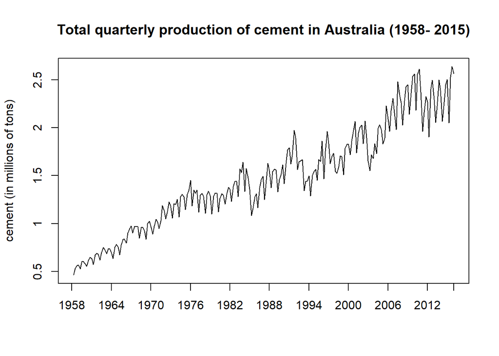

We observe in this first plot a trend component, a possible seasonal component and a growth in the variance.

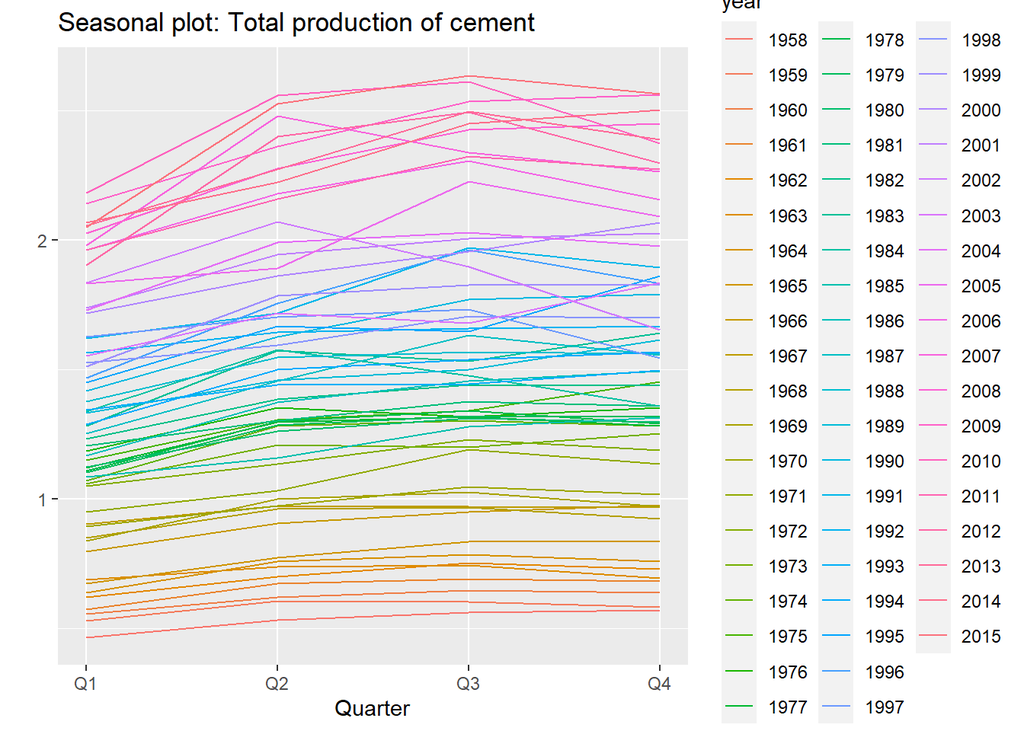

```r
ggseasonplot(z, main='Seasonal plot: Total production of cement')
```

It is clear that the period is s=4 (also we check here the increasing variance and mean).

# Box-Cox transformation

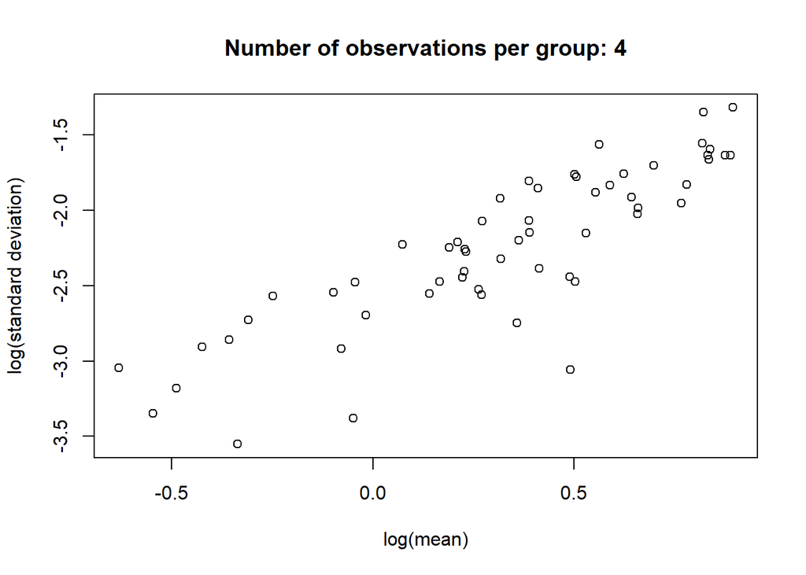

```r
Plot.var(z, n.tilde)
```

There is a linear relationship between the logarithm of the mean and the logarithm of the standard deviation (each dot represents a year). Thus, we can apply the Box-Cox transformation in order to stabilize the variance.

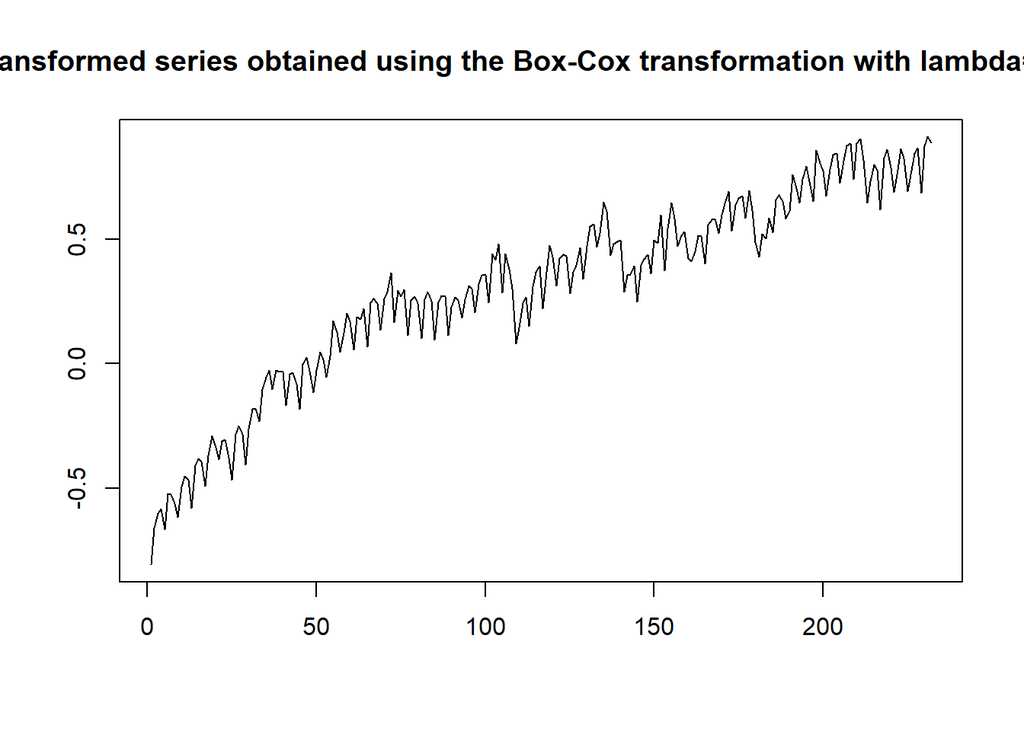

```r
BoxCox(data, n.tilde)
```

Transformed series obtained using the Box-Cox transformation with $\lambda = -0.13$.

Now the variance is constant as we can see.

```r
X.tilde = BoxCox.out(data, n.tilde)
```

# Differentiation

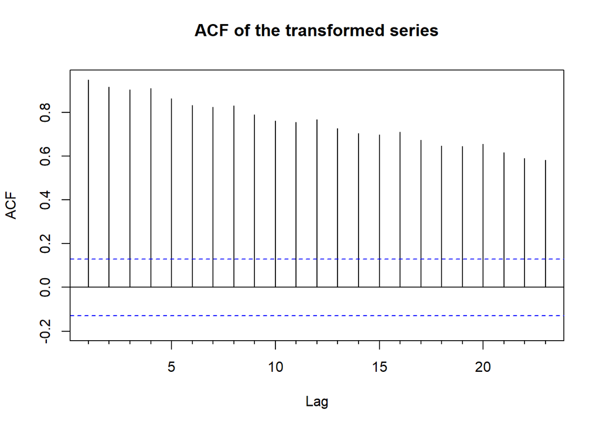

```r
Acf(X.tilde,main="ACF of the transformed series",xlab="Lag",ylab="ACF")
```

Decreases linearly slowly, so we apply the differencing operator.

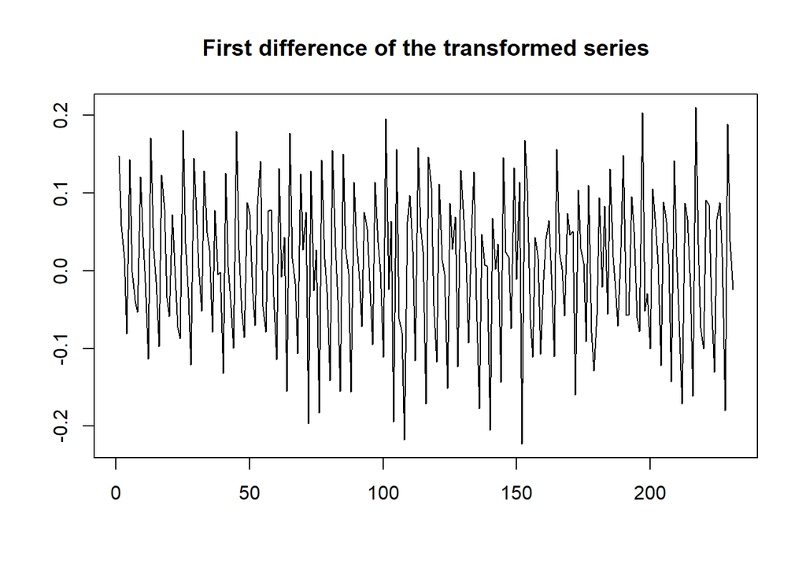

```r
Wt.1 = diff(X.tilde, lag=1, differences=1)
ts.plot(Wt.1, main='First difference of the transformed series', ylab='', xlab='')
```

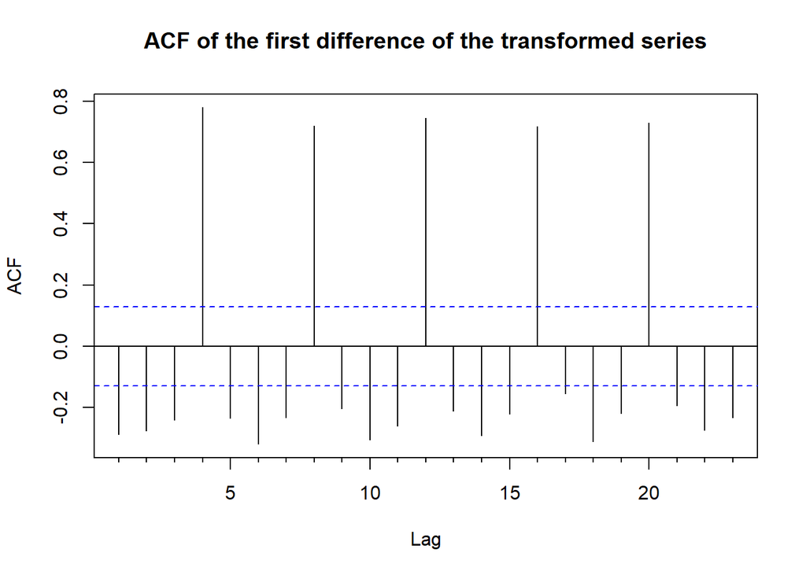

```r
Acf(Wt.1, main="ACF of the first difference of the transformed series",xlab="Lag",ylab="ACF")
```

We see nonzero coefficients on seasonal lags, then we apply seasonal differencing operator (s=4).

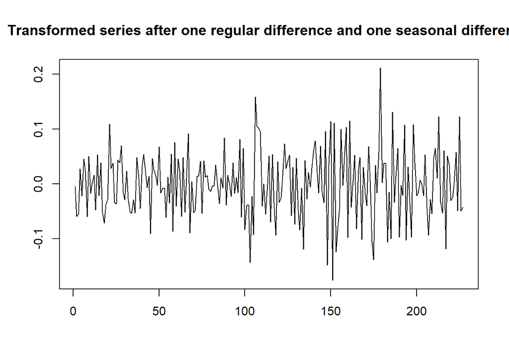

```r
Wt.2 = diff(Wt.1, lag=4, differences = 1)

plot(Wt.2,type='l', main='Transformed series after one regular difference and one seasonal difference', ylab='', xlab='')
```

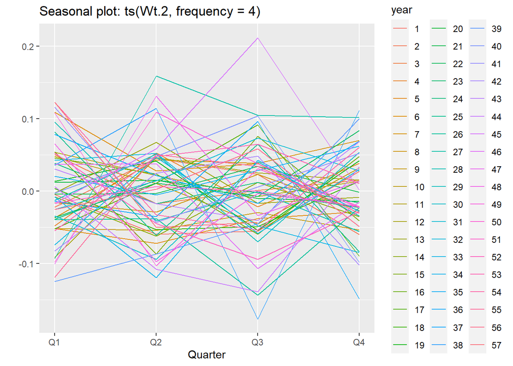

```r
ggseasonplot(ts(Wt.2,frequency=4))
```

Now the series is stationary.

```r
mean(Wt.2)
```

```
## [1] -0.0005275175
```

With mean equal to 0.

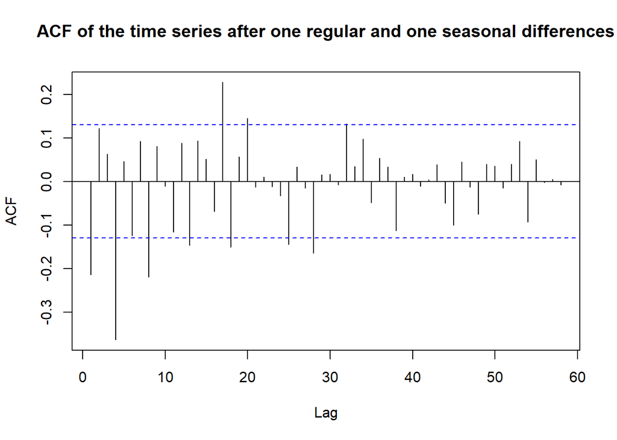

We stop differentiating now because the graph and the ACF do not show obvious deviations from stationarity.  
Here, at first lags we can consider only the first coefficient different from zero or a geometrical decrease. On seasonal lags, only 2 different from zero or geometrical decrease. Between seasonal lags, the interaction of both parts, there are not many lags to conclude anything clearbecause the period is very small.

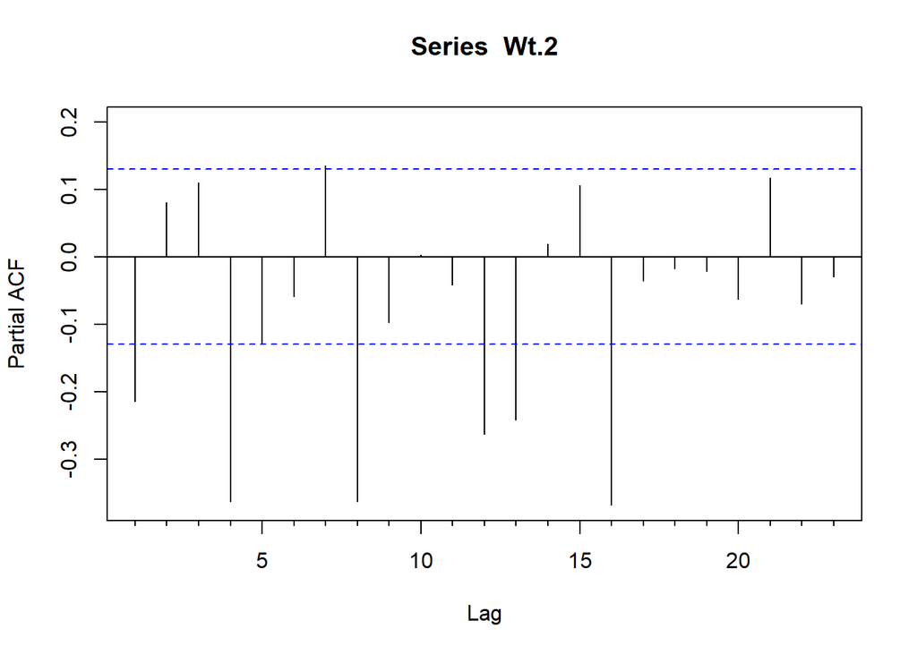

```r
pacf.2=Pacf(Wt.2)
```

At first lags: the first coefficient different from zero or geometrical / sinusoidal decrease. At seasonal lags, the first four coefficients are different from zero. Both to the right and to the left of each seasonal lag, we can’t conclude anything due to the small quantity of coefficients.  
Thus, as a result of the identification step we have identified the following class of models for the “original’’ series $\{{\tilde X}_{t}\}$

- $M_{1}$: ARIMA(4,1,0)$_{4}$x(1,1,1)
- $M_{2}$: ARIMA(4,1,0)$_{4}$x(2,1,1)
- $M_{3}$: ARIMA(4,1,0)$_{4}$x(1,1,0)
- $M_{4}$: ARIMA(4,1,0)$_{4}$x(2,1,0)
- $M_{5}$: ARIMA(2,1,2)$_{4}$x(2,1,0)
- $M_{6}$: ARIMA(2,1,2)$_{4}$x(2,1,1)
- $M_{7}$: ARIMA(2,1,0)$_{4}$x(2,1,0)
- $M_{8}$: ARIMA(2,1,0)$_{4}$x(2,1,1)
- $M_{9}$: ARIMA(2,1,2)$_{4}$x(0,1,1)
- $M_{10}$: ARIMA(2,1,0)$_{4}$x(0,1,1)
- $M_{11}$: ARIMA(4,1,0)$_{4}$x(0,1,1)

### Model Selection

```r
mod1 = Arima(data,order=c(1,1,1),seasonal=list(order=c(4,1,0),period=4),lambda=-0.13)
mod2 = Arima(data,order=c(2,1,1),seasonal=list(order=c(4,1,0),period=4),lambda=-0.13)
mod3 = Arima(data,order=c(1,1,0),seasonal=list(order=c(4,1,0),period=4),lambda=-0.13)
mod4 = Arima(data,order=c(2,1,0),seasonal=list(order=c(4,1,0),period=4),lambda=-0.13)
mod5 = Arima(data,order=c(2,1,0),seasonal=list(order=c(2,1,2),period=4),lambda=-0.13)
mod6 = Arima(data,order=c(2,1,1),seasonal=list(order=c(2,1,2),period=4),lambda=-0.13)
mod7 = Arima(data,order=c(2,1,0),seasonal=list(order=c(2,1,0),period=4),lambda=-0.13)
mod8 = Arima(data,order=c(2,1,1),seasonal=list(order=c(2,1,0),period=4),lambda=-0.13)
mod9 = Arima(data,order=c(0,1,1),seasonal=list(order=c(2,1,2),period=4),lambda=-0.13)
mod10 = Arima(data,order=c(0,1,1),seasonal=list(order=c(2,1,0),period=4),lambda=-0.13)
mod11 = Arima(data,order=c(0,1,1),seasonal=list(order=c(4,1,0),period=4),lambda=-0.13)
```

#### AIC, AICc and BIC:

```r
AIC.BIC=rbind(c(mod1$"aic",mod1$"aicc",mod1$"bic"),
              c(mod2$"aic",mod2$"aicc",mod2$"bic"),
              c(mod3$"aic",mod3$"aicc",mod3$"bic"),
              c(mod4$"aic",mod4$"aicc",mod4$"bic"),
              c(mod5$"aic",mod5$"aicc",mod5$"bic"),
              c(mod6$"aic",mod6$"aicc",mod6$"bic"),
              c(mod7$"aic",mod7$"aicc",mod7$"bic"),
              c(mod8$"aic",mod8$"aicc",mod8$"bic"),
              c(mod9$"aic",mod9$"aicc",mod9$"bic"),
              c(mod10$"aic",mod10$"aicc",mod10$"bic"),
              c(mod11$"aic",mod11$"aicc",mod11$"bic"))

dimnames(AIC.BIC)=list(c("Model 1","Model 2", "Model 3", 'Model 4', "Model 5","Model 6", "Model 7", 'Model 8', 'Model 9', 'Model 10', 'Model 11'),c("AIC","AICc","BIC"))
AIC.BIC
```

```
##                AIC      AICc       BIC
## Model 1  -750.8885 -750.3771 -726.9139
## Model 2  -749.5055 -748.8450 -722.1059
## Model 3  -746.6089 -746.2271 -726.0592
## Model 4  -751.1675 -750.6561 -727.1929
## Model 5  -750.0965 -749.5851 -726.1218
## Model 6  -748.4470 -747.7865 -721.0474
## Model 7  -702.7199 -702.4484 -685.5952
## Model 8  -700.7707 -700.3889 -680.2210
## Model 9  -748.0764 -747.6946 -727.5267
## Model 10 -698.8223 -698.6422 -685.1225
## Model 11 -739.7068 -739.3249 -719.1571
```

Model 4 is the best attending to AIC and AICc. Model 9 is the best by BIC.  
#### Cross-validation:

```r
n.min = 100  # minimal sample size  required to estimate a model
n.data=length(data)
MSE.vec1=numeric(n.data-n.min) # Mean Squared Error model 1
MAE.vec1=numeric(n.data-n.min) # Mean Absolute Error model 1
MSE.vec2=numeric(n.data-n.min) # Mean Squared Error model 2
MAE.vec2=numeric(n.data-n.min) # Mean Absolute Error model 2
MSE.vec3=numeric(n.data-n.min) # Mean Squared Error model 3
MAE.vec3=numeric(n.data-n.min) # Mean Absolute Error model 3
MSE.vec4=numeric(n.data-n.min) # Mean Squared Error model 4
MAE.vec4=numeric(n.data-n.min) # Mean Absolute Error model 4
MSE.vec5=numeric(n.data-n.min) # Mean Squared Error model 5
MAE.vec5=numeric(n.data-n.min) # Mean Absolute Error model 5
MSE.vec6=numeric(n.data-n.min) # Mean Squared Error model 6
MAE.vec6=numeric(n.data-n.min) # Mean Absolute Error model 6
MSE.vec7=numeric(n.data-n.min) # Mean Squared Error model 7
MAE.vec7=numeric(n.data-n.min) # Mean Absolute Error model 7
MSE.vec8=numeric(n.data-n.min) # Mean Squared Error model 8
MAE.vec8=numeric(n.data-n.min) # Mean Absolute Error model 8
MSE.vec9=numeric(n.data-n.min)
MAE.vec9=numeric(n.data-n.min)
MSE.vec10=numeric(n.data-n.min)
MAE.vec10=numeric(n.data-n.min)
MSE.vec11=numeric(n.data-n.min)
MAE.vec11=numeric(n.data-n.min)

for (k in 1:(n.data-n.min))
{
  fit.mod1=Arima(data[1:(n.min+k-1)],order=c(1,1,1),seasonal=list(order=c(4,1,0),period=4),lambda=-0.13)
  forcast.mod1 <- forecast(fit.mod1, h=1)[['mean']]
  fit.mod2=Arima(data[1:(n.min+k-1)],order=c(2,1,1),seasonal=list(order=c(4,1,0),period=4),lambda=-0.13)
  forcast.mod2 <- forecast(fit.mod2, h=1)[['mean']]
  fit.mod3=Arima(data[1:(n.min+k-1)],order=c(1,1,0),seasonal=list(order=c(4,1,0),period=4),lambda=-0.13)
  forcast.mod3 <- forecast(fit.mod3, h=1)[['mean']]
  fit.mod4=Arima(data[1:(n.min+k-1)],order=c(2,1,0),seasonal=list(order=c(4,1,0),period=4),lambda=-0.13)
  forcast.mod4 <- forecast(fit.mod4, h=1)[['mean']]
  fit.mod5=Arima(data[1:(n.min+k-1)],order=c(2,1,0),seasonal=list(order=c(2,1,2),period=4),lambda=-0.13)
  forcast.mod5 <- forecast(fit.mod5, h=1)[['mean']]
  fit.mod6=Arima(data[1:(n.min+k-1)],order=c(2,1,1),seasonal=list(order=c(2,1,2),period=4),lambda=-0.13)
  forcast.mod6 <- forecast(fit.mod6, h=1)[['mean']]
  fit.mod7=Arima(data[1:(n.min+k-1)],order=c(2,1,0),seasonal=list(order=c(2,1,0),period=4),lambda=-0.13)
  forcast.mod7 <- forecast(fit.mod7, h=1)[['mean']]
  fit.mod8=Arima(data[1:(n.min+k-1)],order=c(2,1,1),seasonal=list(order=c(2,1,0),period=4),lambda=-0.13)
  forcast.mod8 <- forecast(fit.mod8, h=1)[['mean']]
  fit.mod9=Arima(data[1:(n.min+k-1)],order=c(0,1,1),seasonal=list(order=c(2,1,2),period=4),lambda=-0.13)
  forcast.mod9 <- forecast(fit.mod9, h=1)[['mean']]
  fit.mod10=Arima(data[1:(n.min+k-1)],order=c(0,1,1),seasonal=list(order=c(2,1,0),period=4),lambda=-0.13)
  forcast.mod10 <- forecast(fit.mod10, h=1)[['mean']]
  fit.mod11=Arima(data[1:(n.min+k-1)],order=c(0,1,1),seasonal=list(order=c(4,1,0),period=4),lambda=-0.13)
  forcast.mod11 <- forecast(fit.mod11, h=1)[['mean']]

  MSE.vec1[k]=(data[(n.min+k)]-forcast.mod1)^2
  MAE.vec1[k]=abs(data[(n.min+k)]-forcast.mod1)
  MSE.vec2[k]=(data[(n.min+k)]-forcast.mod2)^2
  MAE.vec2[k]=abs(data[(n.min+k)]-forcast.mod2)
  MSE.vec3[k]=(data[(n.min+k)]-forcast.mod3)^2
  MAE.vec3[k]=abs(data[(n.min+k)]-forcast.mod3)
  MSE.vec4[k]=(data[(n.min+k)]-forcast.mod4)^2
  MAE.vec4[k]=abs(data[(n.min+k)]-forcast.mod4)
  MSE.vec5[k]=(data[(n.min+k)]-forcast.mod5)^2
  MAE.vec5[k]=abs(data[(n.min+k)]-forcast.mod5)
  MSE.vec6[k]=(data[(n.min+k)]-forcast.mod6)^2
  MAE.vec6[k]=abs(data[(n.min+k)]-forcast.mod6)
  MSE.vec7[k]=(data[(n.min+k)]-forcast.mod7)^2
  MAE.vec7[k]=abs(data[(n.min+k)]-forcast.mod7)
  MSE.vec8[k]=(data[(n.min+k)]-forcast.mod8)^2
  MAE.vec8[k]=abs(data[(n.min+k)]-forcast.mod8)
  MSE.vec9[k]=(data[(n.min+k)]-forcast.mod9)^2
  MAE.vec9[k]=abs(data[(n.min+k)]-forcast.mod9)
  MSE.vec10[k]=(data[(n.min+k)]-forcast.mod10)^2
  MAE.vec10[k]=abs(data[(n.min+k)]-forcast.mod10)
  MSE.vec11[k]=(data[(n.min+k)]-forcast.mod11)^2
  MAE.vec11[k]=abs(data[(n.min+k)]-forcast.mod11)
  if (k==104){break}
}
```

```r
# Summary Results

Results.mat=rbind(
  apply(cbind(MSE.vec1,MSE.vec2,MSE.vec3,MSE.vec4,MSE.vec5,MSE.vec6,MSE.vec7,MSE.vec8,MSE.vec9,MSE.vec10,MSE.vec11)[-132,],2,mean),
  apply(cbind(MAE.vec1,MAE.vec2,MAE.vec3,MAE.vec4,MAE.vec5,MAE.vec6,MAE.vec7,MAE.vec8,MAE.vec9,MAE.vec10,MAE.vec11)[-132,],2,mean)
)
dimnames(Results.mat)=list(c("MSE","MAE"),c("Model 1","Model 2", "Model 3", 'Model 4', "Model 5","Model 6", "Model 7", 'Model 8', 'Model 9', 'Model 10', 'Model 11'))

Results.mat
```

```
##         Model 1     Model 2     Model 3     Model 4     Model 5    Model 6
## MSE 0.007999594 0.008134682 0.008042587 0.008030875 0.008194208 0.00832148
## MAE 0.061205271 0.061226890 0.062964471 0.060968240 0.062454227 0.06297466
##        Model 7    Model 8     Model 9   Model 10    Model 11
## MSE 0.01116285 0.01127793 0.008074676 0.01121649 0.008360337
## MAE 0.07135608 0.07158024 0.063949660 0.07345439 0.065368255
```

```r
require(astsa)
source('Diagnostic.R')
require(portes)
require(nortest)
```

#### Model 4.

Test the null hypothesis that the residuals are realizations of an IID noise process.

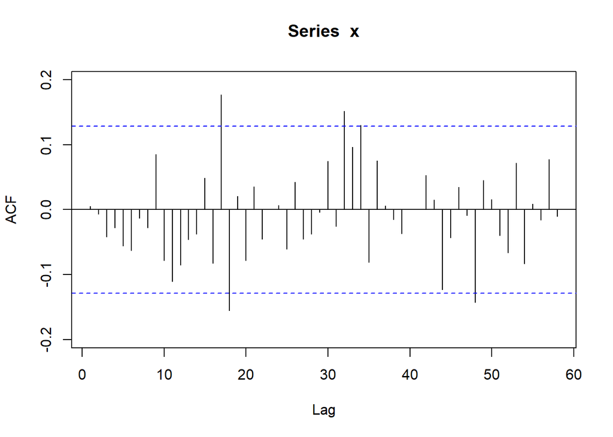

```
##                   [,1]
## n               232.00
## h                58.00
## bound             0.13
## # out of bounds   5.00
## % out of bounds   8.62
```

```r
S.ACF(mod4$residuals)
```

```r
NonParametric.Tests(mod4$residuals)
```

```
##                      Test Statistic    P-value
## Turning Point test        1.6153284 0.10623959
## Difference-sign Test      1.7020563 0.08874481
## Rank Test                 0.7040819 0.48138178
```

For the Ljung.Box test: the time series is seasonal with period s,then lag=min(2s,n/5) = 8

[figure not shown]

```
##      k Test Statistic   P-value
## [1,] 8        2.54249 0.1108199
```

```r
My.Ljung.Box(mod4$residuals, 7)
```

Test the null hypothesis that the residuals follow a Normal distribution

```r
Check.normality(mod4$residuals)
```

```
##                    Statistics P-value
## Shapiro-Wilxs          0.9915  0.1982
## Lilliefors             0.0550  0.0850
## Pearson Chi.square    19.8448  0.1780
```

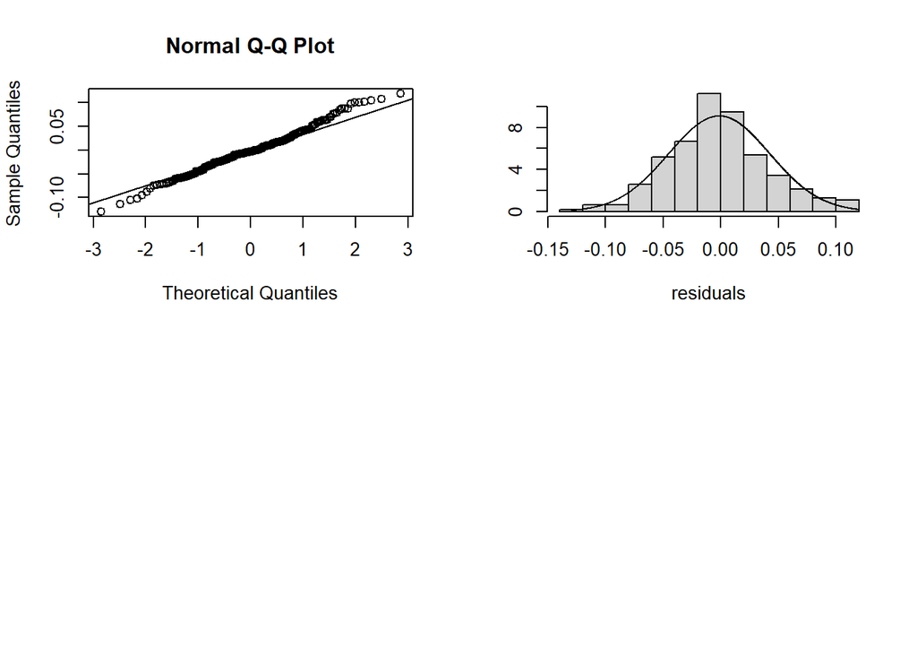

#### Model 5.

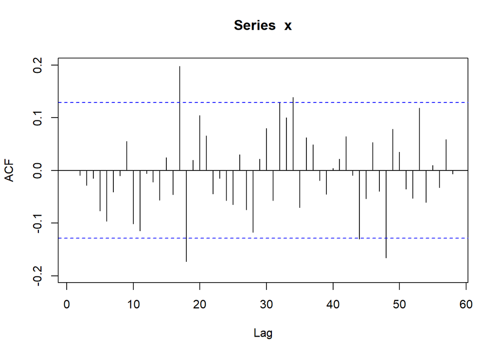

```
##                   [,1]
## n               232.00
## h                58.00
## bound             0.13
## # out of bounds   5.00
## % out of bounds   8.62
```

```r
S.ACF(mod5$residuals)
```

```r
NonParametric.Tests(mod5$residuals)
```

```
##                      Test Statistic    P-value
## Turning Point test        0.6773958 0.49815487
## Difference-sign Test      1.9289972 0.05373121
## Rank Test                 1.0239653 0.30585169
```

```r
Check.normality(mod5$residuals)
```

```
##                    Statistics P-value
## Shapiro-Wilxs          0.9913  0.1801
## Lilliefors             0.0472  0.2358
## Pearson Chi.square    19.2241  0.2038
```

```r
My.Ljung.Box(mod5$residuals,7)
```

```
##      k Test Statistic    P-value
## [1,] 8       4.327101 0.03751008
```

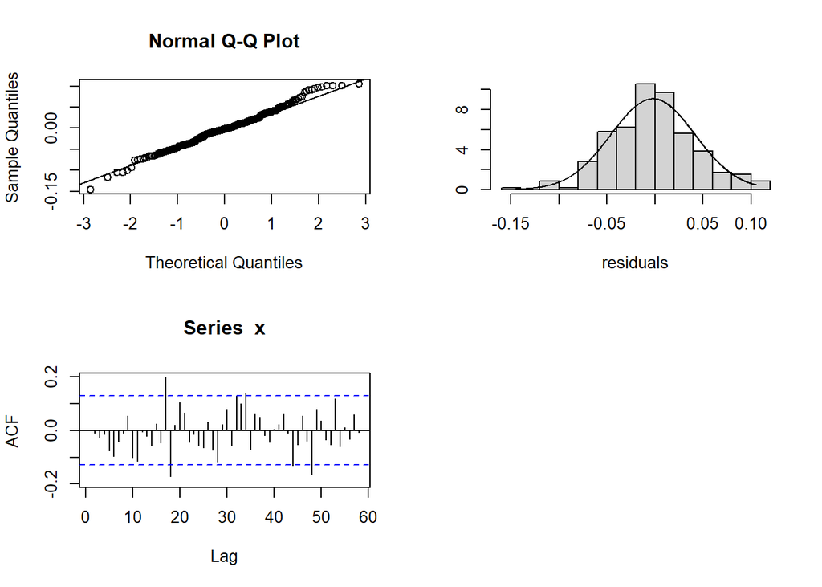

#### Model 9.

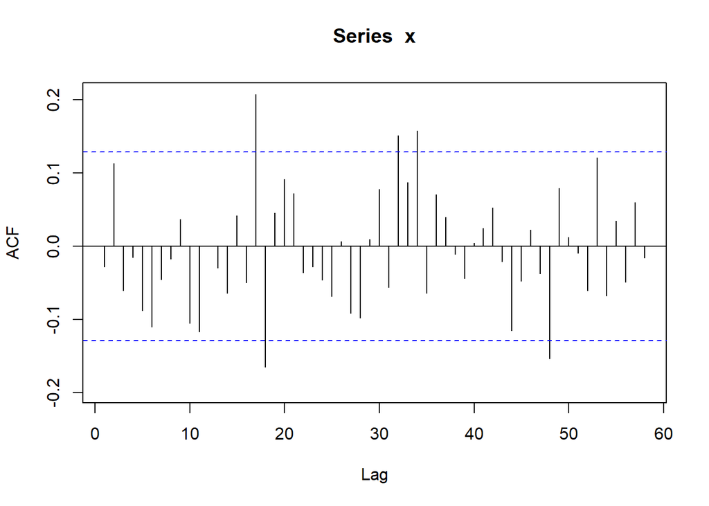

```
##                   [,1]
## n               232.00
## h                58.00
## bound             0.13
## # out of bounds   5.00
## % out of bounds   8.62
```

```r
S.ACF(mod9$residuals)
```

```r
NonParametric.Tests(mod9$residuals)
```

```
##                      Test Statistic   P-value
## Turning Point test         1.198469 0.2307343
## Difference-sign Test       1.021234 0.3071437
## Rank Test                  1.022273 0.3066518
```

```r
Check.normality(mod9$residuals)
```

```
##                    Statistics P-value
## Shapiro-Wilxs          0.9931  0.3529
## Lilliefors             0.0452  0.2958
## Pearson Chi.square    17.9828  0.2636
```

```r
My.Ljung.Box(mod9$residuals,6)
```

```
##      k Test Statistic     P-value
## [1,] 8       9.401143 0.009090079
```

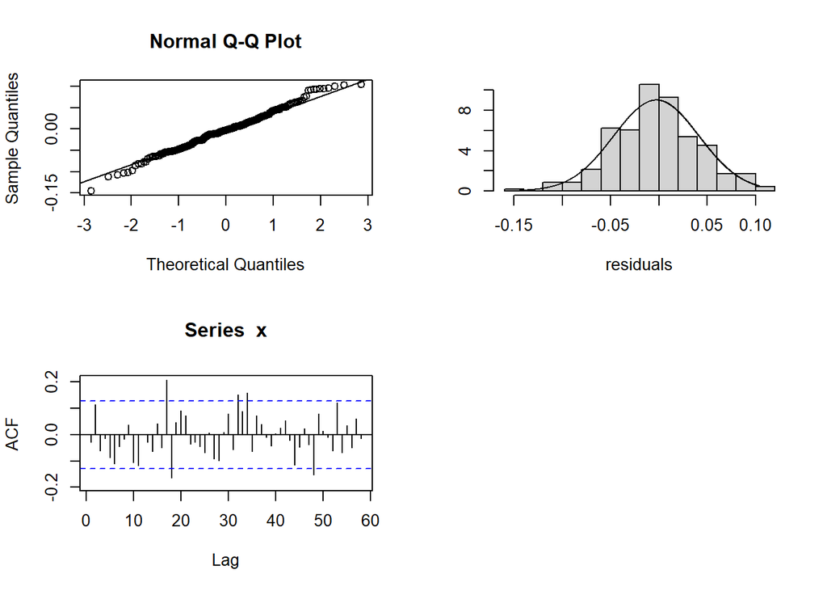

We only can conclude with the Ljung-Box test (the rest do not make differences). We choose Model 4 as the best model overall.

### Model fit and prediction

Fit to the original data

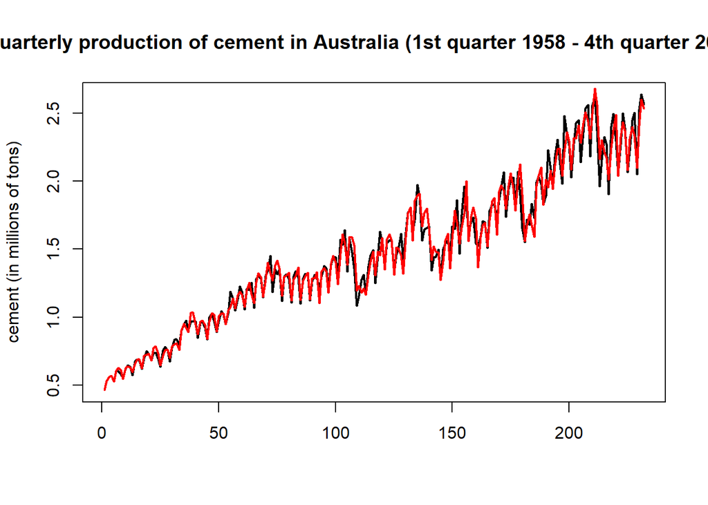

```r
plot(seq(1,232), data,ylab="cement (in millions of tons)",xlab="",type="l",main="Total quarterly production of cement in Australia (1st quarter 1958 - 4th quarter 2015), n=232",lwd=2)
points(seq(1,232),forecast(mod4)$fitted,col="red",type="l",lwd=2)
```

```r
n.data=length(data)
fit.mod4=Arima(data[1:224],order=c(2,1,0),seasonal=list(order=c(4,1,0),period=4 ),lambda=-0.13)
forcast.mod4 <- forecast(fit.mod4, h=8) #predicciones
```

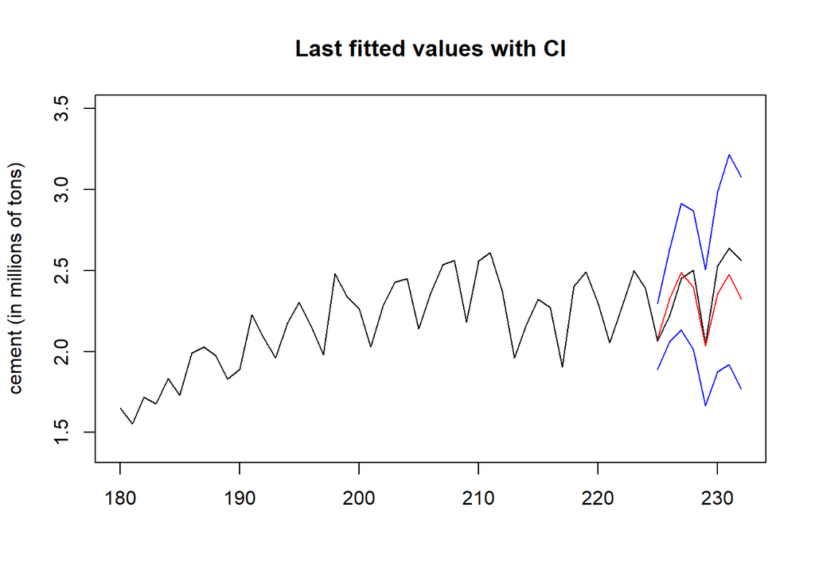

```r
plot(seq(180,232), data[180:232],ylab="cement (in millions of tons)",xlab="",type="l",main="Last fitted values with CI",ylim=c(1.4,3.5))
points(seq(225,232),forcast.mod4$mean,type="l",col="red") # predictions
points(seq(225,232),forcast.mod4$lower[,2],type="l",col="blue") # lower CI
points(seq(225,232),forcast.mod4$upper[,2],type="l",col="blue") # up CI
```

### Predictions

```r
Predic.mod4=forecast(mod4,20)
Predic.mod4
```

```
##     Point Forecast    Lo 80    Hi 80    Lo 95    Hi 95
## 233       2.138964 2.007821 2.279868 1.942092 2.358686
## 234       2.501570 2.310403 2.710804 2.215923 2.829528
## 235       2.661734 2.403995 2.951137 2.279050 3.118631
## 236       2.559811 2.281217 2.877465 2.147716 3.063509
## 237       2.181942 1.909976 2.498485 1.781651 2.686865
## 238       2.549157 2.192102 2.973334 2.026197 3.229829
## 239       2.730329 2.308183 3.241814 2.114905 3.555897
## 240       2.616959 2.184998 3.147924 1.989341 3.477660
## 241       2.251754 1.860485 2.738578 1.684856 3.043791
## 242       2.568349 2.088811 3.176047 1.876482 3.562565
## 243       2.779772 2.228290 3.490515 1.987140 3.948598
## 244       2.707773 2.147509 3.438888 1.904772 3.914747
## 245       2.288534 1.795902 2.939394 1.584411 3.367168
## 246       2.619956 2.020104 3.428981 1.766475 3.969434
## 247       2.822552 2.140720 3.760121 1.856511 4.396117
## 248       2.785739 2.087052 3.760446 1.798890 4.429242
## 249       2.321958 1.719529 3.173952 1.473548 3.764930
## 250       2.758948 1.998183 3.863545 1.693474 4.645943
## 251       2.929103 2.081529 4.187762 1.747582 5.095441
## 252       2.839911 1.990942 4.121156 1.660351 5.057120
```

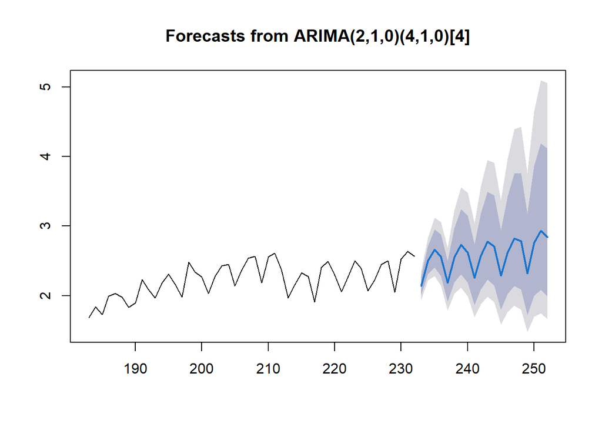

```r
plot(Predic.mod4,50)
```